# 2020Apr

Zongchao Liu

4/9/2020

# import and clean the dataset for patients’ information

```r
outcome_df = read_csv('./data/factors_outcomes.csv') %>%
 rename("name" = "names_eng" ,
        "age" = "年龄",
        "sex" = "性别",
        "group" = "组别（无序分类）",
        "cT" = "cT（有序分类）",
        "cN" = "cN（有序分类）",
        "MRF" = "MRF阳性（二分类）",
        "tumor_length" = "肿瘤长度（连续数值）",
        "tumor_thickness" = "肿瘤厚度（连续数值）",
        "distance" = "治疗前肛缘距离（连续数值）",
        "path" = "活检病理类型（无序分类）",
        "CEA" = "治疗前CEA（连续数值）",
        "differentiation" = "活检分化程度（有序分类）"
        ) %>%
  mutate(name = recode(name,
                       "cengrenyong" = "zengrenyong",
                       "huanghuaxing" = "huanghuaxin",
                       "licaiqun" = "licaiqun2",
                       "lijiabin" = "lijiabing",
                       "wugenghui" = "wugenghui2",
                       "yanpinggen" = "yangpinggen",
                       "yinshaozeng" = "yinshaozhen",
                       "chenqiuru" = "chenqiru"
                       ),
         PCR = factor(PCR),
         differentiation = factor(differentiation),
         sex = recode(sex,
                      "男" = "male",
                      "女" = "female"),
         group = as.character(group),
         cT = factor(cT),
         cN = factor(cN),
         MRF = as.character(MRF),
         path = as.character(path)) %>%
  arrange(name) %>%
  .[15]

outcome_df_2020 = read_xlsx('./副本outcome_2020_4.xlsx') %>%
 rename("name" = "姓名" ,
        "age" = "年龄",
        "sex" = "性别",
        "group" = "组别（无序分类）",
        "cT" = "cT（有序分类）",
        "cN" = "cN（二分类）",
        "MRF" = "MRF阳性（二分类）",
        "tumor_length" = "肿瘤长度（连续数值）",
        "tumor_thickness" = "肿瘤厚度（连续数值）",
        "distance" = "治疗前肛缘距离（连续数值）",
        "path" = "活检病理类型（无序分类）",
        "CEA" = "治疗前CEA（连续数值）",
        "differentiation" = "活检分化程度（有序分类）"
        ) %>%
  mutate(
         PCR = factor(PCR),
         differentiation = factor(differentiation),
         sex = recode(sex,
                      "男" = "male",
                      "女" = "female"),
         group = as.character(group),
         cT = factor(cT),
         cN = factor(cN),
         MRF = as.character(MRF),
         path = as.character(path))
```

# The following is only for Logistic LASSO Regression Analysis

```r
# import and clean data
features = read_csv("./data/feature_extracted_2019_1.csv") %>%
  janitor::clean_names() %>%
  mutate(id = c(1:64)) %>%
  select(-x1) %>%
  select(id,everything())

# import and clean data(2020.4)
features_1 = read_csv("./feature_extracted_2020_APR.csv") %>%
  janitor::clean_names() %>%
  mutate(id = c((1+64):(nrow(.)+64))) %>%
  select(-x1) %>%
  select(id,everything())
features_1 = features_1[,-c(2:38)]

# row-bind current data
# 挑选出可以用于回归的变量
feature_for_lasso = features[,-c(2:38)] %>%
  rbind(.,features_1)

# 获取观测值姓名信息
file_names = tibble(
  names = list.files("./done")) %>%
  filter(str_detect(names, "-") == FALSE)

file_names_2020 = outcome_df_2020$name[1:36]
PCR_2020 = outcome_df_2020$PCR[1:36]

# 匹配姓名与CT影像特征数据
PCR_2019 = outcome_df$PCR
PCR = factor(as.numeric(c(PCR_2019,PCR_2020))-1)


feature_for_lasso = feature_for_lasso %>%
  mutate(PCR = PCR) %>%
  select(PCR,id,everything()) %>%
  as.tibble()# final data for 2020

rm(features)
rm(file_names)
```

## LASSO

### do the regression work

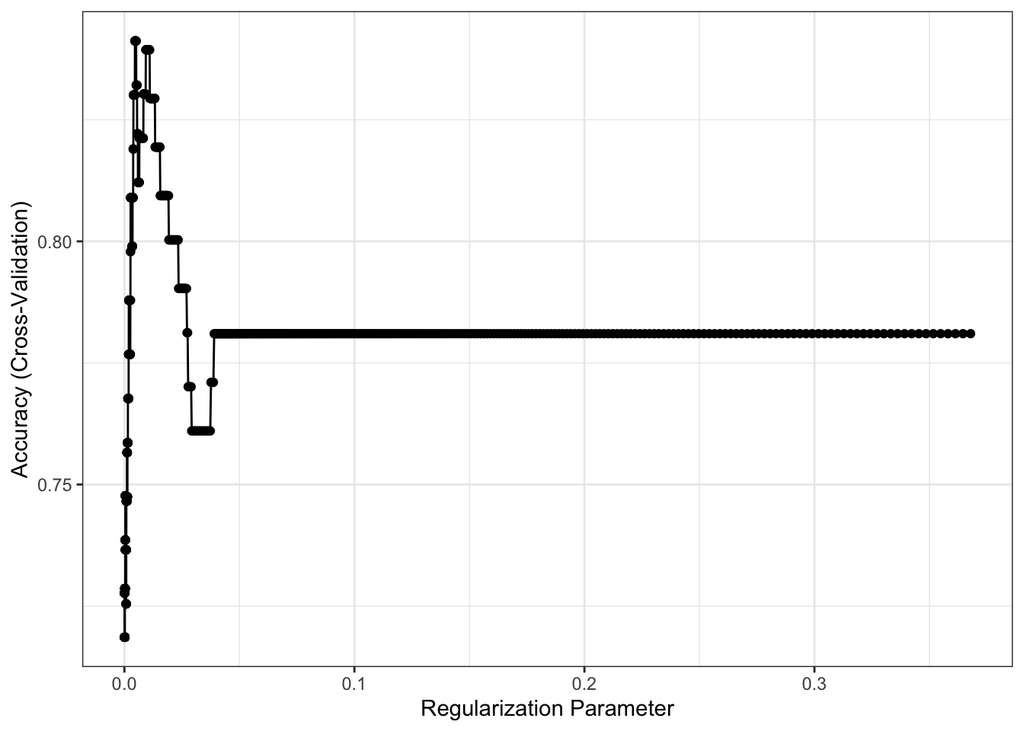

```r
data_reg = feature_for_lasso[-2]

x = model.matrix(PCR ~ . , data_reg)[,-1] %>% as.tibble() %>%
  .[features_into_account] %>% #1 :1031 ,1:831
  as.matrix()
y = feature_for_lasso$PCR


ctrl1  = trainControl(method = "cv", number = 10)

set.seed(2)
lasso.fit = train(x, y,method = "glmnet",
                  tuneGrid = expand.grid(alpha = 1,lambda =exp(seq(-10, -1, length=1000))),
        preProc = c("center", "scale"),
        trControl = ctrl1)


ridge.fit = train(x, y,method = "glmnet",
                  tuneGrid = expand.grid(alpha = 1,lambda =exp(seq(-10, -1, length=1000))),
        preProc = c("center", "scale"),
        trControl = ctrl1)





ggplot(lasso.fit) +
  theme_bw()
```

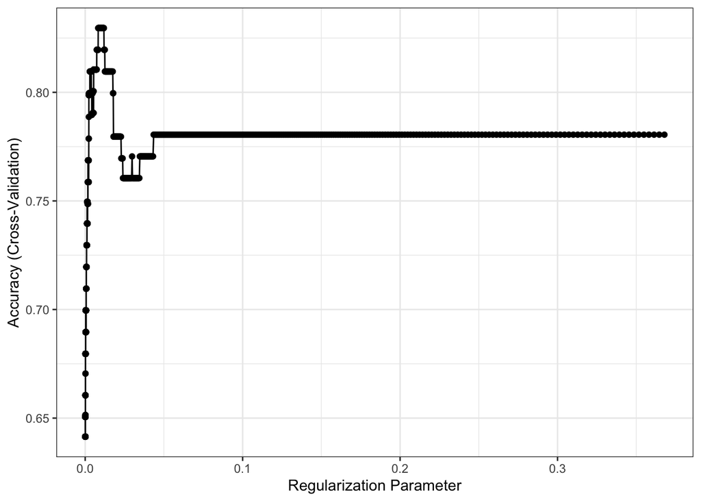

```r
ggplot(ridge.fit) +
  theme_bw()
```

#### check model

```r
lasso.fit$bestTune #best lambda
```

```
##     alpha      lambda
## 525     1 0.005096102
```

```r
lasso.fit$metric
```

```
## [1] "Accuracy"
```

```r
lasso.fit$preProcess
```

```
## Created from 100 samples and 59 variables
##
## Pre-processing:
##   - centered (59)
##   - ignored (0)
##   - scaled (59)
```

```r
coef = data.frame(as.matrix(coef(lasso.fit$finalModel,lasso.fit$bestTune$lambda)))
coef = coef %>%
  mutate(coef = rownames(coef)) %>%
  rename("value" = "X1") %>%
  filter(value !=0)

coef %>%
  filter(value !=0) %>%
  nrow() # number of useful predictors
```

```
## [1] 20
```

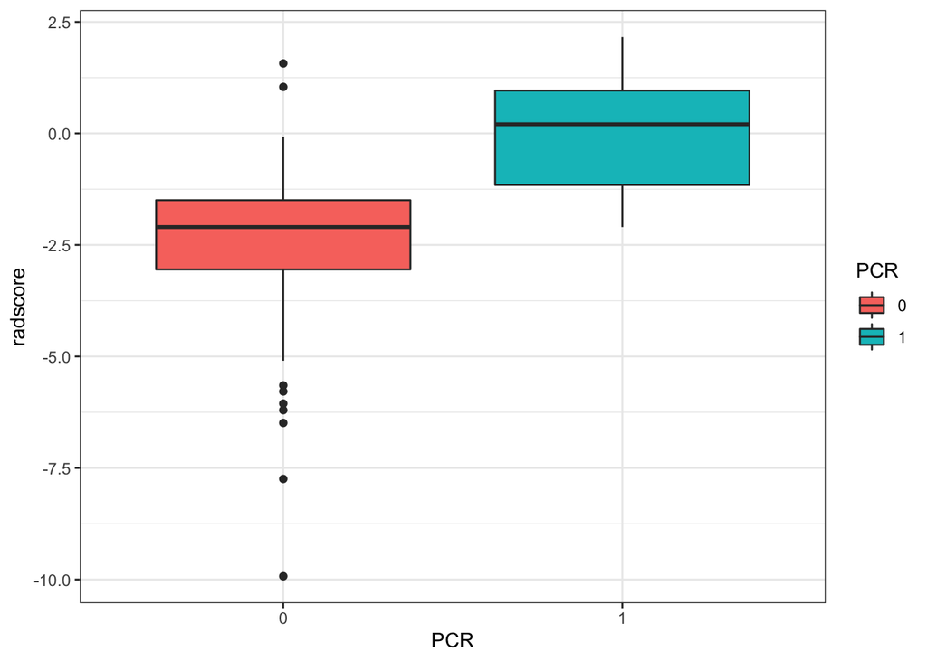

```r
# The selected predictors are:
predictors = coef$coef[-1] #plus intercept

# the next step is to calculate radscores:

predictors_val = coef$value[-1]


feature_matrix = feature_for_lasso[predictors] %>% as.matrix() %>% scale()
coef_matrix = predictors_val %>% as.matrix()

radscore = feature_matrix %*% coef_matrix + coef$value[1]
radscore_df = tibble(PCR = PCR,
                     radscore = radscore)

radscore_df %>%
  ggplot(aes(x = PCR,
             y = radscore, fill = PCR)) +
  geom_boxplot() +
  theme_bw()
```

```r
# cal radscoe by using ridge regression
#
#coef = data.frame(as.matrix(coef(ridge.fit$finalModel,ridge.fit$bestTune$lambda)))
#coef = coef %>%
#  mutate(coef = rownames(coef)) %>%
#  rename("value" = "X1") %>%
#  filter(value !=0)
```

# logistic reg

```r
outcome_df_2020 = outcome_df_2020 %>%
  mutate(PCR = factor(as.numeric(c(PCR_2020,PCR_2019))-1),
         radscore = c(radscore[65:100],radscore[1:64]),
         group = factor(recode(group,
                        "A" = "1",
                        "B" = "2",
                        "C" = "3",
                        "c" = "3")),
         cTNM = factor(cTNM))

logistic.fit = glm(PCR ~ radscore, data = radscore_df, family = binomial(link = "logit")) # only radscore

logistic.fit_norad = glm(PCR ~ tumor_thickness, data = outcome_df_2020, family = binomial(link = "logit")) # a lot

summary(logistic.fit)
```

```
##
## Call:
## glm(formula = PCR ~ radscore, family = binomial(link = "logit"),
##     data = radscore_df)
##
## Deviance Residuals:
##      Min        1Q    Median        3Q       Max
## -2.19332  -0.50786  -0.30414  -0.02782   2.24943
##
## Coefficients:
##             Estimate Std. Error z value Pr(>|z|)
## (Intercept)   0.2764     0.4098   0.674      0.5
## radscore      1.2971     0.2867   4.525 6.04e-06 ***
## ---
## Signif. codes:  0 '***' 0.001 '**' 0.01 '*' 0.05 '.' 0.1 ' ' 1
##
## (Dispersion parameter for binomial family taken to be 1)
##
##     Null deviance: 105.382  on 99  degrees of freedom
## Residual deviance:  65.723  on 98  degrees of freedom
## AIC: 69.723
##
## Number of Fisher Scoring iterations: 6
```

```r
summary(logistic.fit_norad)
```

```
##
## Call:
## glm(formula = PCR ~ tumor_thickness, family = binomial(link = "logit"),
##     data = outcome_df_2020)
##
## Deviance Residuals:
##     Min       1Q   Median       3Q      Max
## -0.7519  -0.7275  -0.7036  -0.6276   1.7928
##
## Coefficients:
##                 Estimate Std. Error z value Pr(>|z|)
## (Intercept)     -0.96750    0.72780  -1.329    0.184
## tumor_thickness -0.01890    0.04601  -0.411    0.681
##
## (Dispersion parameter for binomial family taken to be 1)
##
##     Null deviance: 104.88  on 98  degrees of freedom
## Residual deviance: 104.70  on 97  degrees of freedom
##   (1 observation deleted due to missingness)
## AIC: 108.7
##
## Number of Fisher Scoring iterations: 4
```

```r
outcome_df_2020$PCR
```

```
##   [1] 0 0 0 1 0 0 0 0 0 1 0 0 0 0 1 1 0 1 0 0 0 0 0 0 0 0 0 0 0 1 0 0 0 1 0
##  [36] 0 1 0 0 1 0 0 0 0 0 1 0 0 0 1 1 0 0 0 1 0 0 0 0 0 0 1 1 0 0 0 0 1 1 0
##  [71] 0 0 0 0 0 0 0 0 1 0 0 0 1 0 0 0 0 0 0 1 1 0 0 0 1 0 0 0 0 0
## Levels: 0 1
```

```r
radscore_df$PCR
```

```
##   [1] 1 0 0 1 0 0 0 0 0 1 0 0 0 1 1 0 0 0 1 0 0 0 0 0 0 1 1 0 0 0 0 1 1 0 0
##  [36] 0 0 0 0 0 0 0 1 0 0 0 1 0 0 0 0 0 0 1 1 0 0 0 1 0 0 0 0 0 0 0 0 1 0 0
##  [71] 0 0 0 1 0 0 0 0 1 1 0 1 0 0 0 0 0 0 0 0 0 0 0 1 0 0 0 1 0 0
## Levels: 0 1
```

# EDA

```r
library(kableExtra)
library(knitr)
library(arsenal)
names(outcome_df_2020)
```

```
##  [1] "name"            "age"             "sex"
##  [4] "group"           "cT"              "cN"
##  [7] "cTNM"            "MRF"             "tumor_length"
## [10] "tumor_thickness" "distance"        "CEA"
## [13] "path"            "differentiation" "PCR"
## [16] "radscore"
```

```r
control <- arsenal::tableby.control(test = T,
                                    numeric.stats = c("meansd","medianq1q3","range"),
                                    cat.stats = c("countrowpct"),
                                    ordered.stats = c("Nmiss"),
                                    digits = 2)
tbl <- arsenal::tableby(PCR ~ age + sex + group + cT +cN +cTNM +MRF + tumor_length + tumor_thickness + distance +CEA + path +differentiation + radscore, data = outcome_df_2020, control = control)

summary(tbl,text = T) %>%
  knitr::kable(booktabs = T, caption = "Descriptive Statistics") %>%
  kable_styling(latex_options = c("striped", "hold_position"))
```

Descriptive Statistics

0 (N=78)

1 (N=22)

Total (N=100)

p value

age

0.621

- Mean (SD)

53.31 (13.54)

51.68 (13.73)

52.95 (13.53)

- Median (Q1, Q3)

56.00 (42.25, 65.00)

51.00 (39.00, 63.25)

55.00 (41.75, 64.25)

- Range

21.00 - 77.00

30.00 - 73.00

21.00 - 77.00

sex

0.894

- female

26 (78.8%)

7 (21.2%)

33 (100.0%)

- male

52 (77.6%)

15 (22.4%)

67 (100.0%)

group

< 0.001

- 1

26 (89.7%)

3 (10.3%)

29 (100.0%)

- 2

16 (50.0%)

16 (50.0%)

32 (100.0%)

- 3

36 (92.3%)

3 (7.7%)

39 (100.0%)

cT

0.492

- 2

1 (50.0%)

1 (50.0%)

2 (100.0%)

- 3

67 (79.8%)

17 (20.2%)

84 (100.0%)

- 4

10 (71.4%)

4 (28.6%)

14 (100.0%)

cN

0.284

- 0

19 (86.4%)

3 (13.6%)

22 (100.0%)

- 1

59 (75.6%)

19 (24.4%)

78 (100.0%)

cTNM

0.138

- 1

0 (0.0%)

1 (100.0%)

1 (100.0%)

- 2

20 (83.3%)

4 (16.7%)

24 (100.0%)

- 3

58 (77.3%)

17 (22.7%)

75 (100.0%)

MRF

0.707

- 0

59 (78.7%)

16 (21.3%)

75 (100.0%)

- 1

18 (75.0%)

6 (25.0%)

24 (100.0%)

tumor_length

0.213

- Mean (SD)

4.24 (1.45)

3.80 (1.36)

4.14 (1.43)

- Median (Q1, Q3)

4.00 (3.20, 4.90)

3.50 (3.00, 5.12)

4.00 (3.00, 4.95)

- Range

2.00 - 8.70

1.40 - 6.50

1.40 - 8.70

tumor_thickness

0.684

- Mean (SD)

15.40 (6.39)

14.82 (3.53)

15.27 (5.86)

- Median (Q1, Q3)

14.00 (12.00, 17.00)

14.50 (13.00, 16.00)

14.00 (12.00, 17.00)

- Range

8.00 - 51.00

9.00 - 22.00

8.00 - 51.00

distance

0.137

- Mean (SD)

6.28 (2.71)

5.32 (2.37)

6.07 (2.66)

- Median (Q1, Q3)

6.40 (4.00, 8.35)

5.60 (3.50, 7.00)

6.20 (3.72, 8.00)

- Range

1.70 - 12.00

1.70 - 10.90

1.70 - 12.00

CEA

0.792

- Mean (SD)

8.97 (18.54)

10.11 (15.22)

9.22 (17.80)

- Median (Q1, Q3)

2.99 (1.63, 6.04)

2.80 (1.49, 10.72)

2.92 (1.60, 6.88)

- Range

0.50 - 110.02

0.50 - 53.63

0.50 - 110.02

path

0.396

- 0

2 (50.0%)

2 (50.0%)

4 (100.0%)

- 1

72 (80.0%)

18 (20.0%)

90 (100.0%)

- 2

3 (75.0%)

1 (25.0%)

4 (100.0%)

- 3

1 (50.0%)

1 (50.0%)

2 (100.0%)

differentiation

0.467

- 0

4 (57.1%)

3 (42.9%)

7 (100.0%)

- 1

30 (81.1%)

7 (18.9%)

37 (100.0%)

- 2

34 (81.0%)

8 (19.0%)

42 (100.0%)

- 3

10 (71.4%)

4 (28.6%)

14 (100.0%)

radscore

< 0.001

- Mean (SD)

-2.49 (1.83)

-0.04 (1.27)

-1.95 (1.99)

- Median (Q1, Q3)

-2.10 (-3.05, -1.50)

0.21 (-1.16, 0.96)

-1.89 (-2.86, -0.95)

- Range

-9.93 - 1.57

-2.10 - 2.16

-9.93 - 2.16